# Intrinsic Motivation

### [Home](https://pbischoff3.github.io/) | [Data Overview](https://pbischoff3.github.io/data_overview/) | [Multi-Dimensional Analysis](https://pbischoff3.github.io/multi_dimensional_analysis/) | [Models](https://pbischoff3.github.io/models/) | [Conclusion](https://pbischoff3.github.io/Conclusion/)

Let’s check out Intrinsic Motivation models.

## Major

Let’s see the influence that the difference in majors have an the average of Intrinsic Motivation questions:

```
##
## Call:
## glm(formula = intrinsic_mot_ave ~ major, data = df)
##
## Deviance Residuals:
##     Min       1Q   Median       3Q      Max
## -3.1690  -0.3299   0.2506   0.6793   1.2701
##
## Coefficients:
##                   Estimate Std. Error t value Pr(>|t|)
## (Intercept)        4.16901    0.12011  34.711   <2e-16 ***
## majorChemistry     0.03099    0.40093   0.077   0.9384
## majorComputer_sci  0.43099    0.40093   1.075   0.2832
## majorEarth_sci     0.03099    1.01915   0.030   0.9758
## majorEngineering   0.12432    0.28759   0.432   0.6658
## majorHealth_sci   -0.43914    0.14518  -3.025   0.0027 **
## majorMathematics  -0.26901    0.72563  -0.371   0.7111
## majorNon_STEM     -0.07336    0.24281  -0.302   0.7628
## majorOther        -0.33776    0.21548  -1.567   0.1180
## ---
## Signif. codes:  0 '***' 0.001 '**' 0.01 '*' 0.05 '.' 0.1 ' ' 1
##
## (Dispersion parameter for gaussian family taken to be 1.024231)
##
##     Null deviance: 327.21  on 311  degrees of freedom
## Residual deviance: 310.34  on 303  degrees of freedom
## AIC: 903.76
##
## Number of Fisher Scoring iterations: 2
```

This shows that those who study Health Science majors answer significantly lower Intrinsic Motivation than the rest of the groups of majors.

This is great, but it is difficult to understand this in context until we compare it to the other models.

## Career

Now, let’s look at how career goals affect the average of Intrinsic Motivation questions:

```
##
## Call:
## glm(formula = intrinsic_mot_ave ~ career, data = df)
##
## Deviance Residuals:
##     Min       1Q   Median       3Q      Max
## -3.2667  -0.3340   0.2639   0.7333   1.2639
##
## Coefficients:
##                       Estimate Std. Error t value Pr(>|t|)
## (Intercept)            3.88889    0.15229  25.535   <2e-16 ***
## careereducator         0.38803    0.32168   1.206    0.229
## careerengineer         0.32444    0.30459   1.065    0.288
## careerhealth_care_pro -0.15282    0.17818  -0.858    0.392
## careermedical_doctor   0.13889    0.19414   0.715    0.475
## careernon_stem         0.12111    0.27455   0.441    0.659
## careerresearcher       0.48254    0.41508   1.163    0.246
## careerscientist        0.37778    0.33192   1.138    0.256
## careertechnician       0.04444    0.44401   0.100    0.920
## ---
## Signif. codes:  0 '***' 0.001 '**' 0.01 '*' 0.05 '.' 0.1 ' ' 1
##
## (Dispersion parameter for gaussian family taken to be 1.043706)
##
##     Null deviance: 327.21  on 311  degrees of freedom
## Residual deviance: 316.24  on 303  degrees of freedom
## AIC: 909.63
##
## Number of Fisher Scoring iterations: 2
```

This shows that there are no significant differences between career goals and Intrinsic Motivation.

Now let’s run from another model’s point of view.

## Ethnicity

How about we look at how different ethnicities affect Intrinsic Motivation?

```
##
## Call:
## glm(formula = intrinsic_mot_ave ~ ethnicity, data = df)
##
## Deviance Residuals:
##     Min       1Q   Median       3Q      Max
## -3.0353  -0.3653   0.2347   0.6348   3.1200
##
## Coefficients:
##                            Estimate Std. Error t value Pr(>|t|)
## (Intercept)                  1.8800     0.4432   4.242 2.95e-05 ***
## ethnicityamerican_indian     2.2700     0.6648   3.415 0.000726 ***
## ethnicityarab                3.1200     1.0856   2.874 0.004341 **
## ethnicityasian               2.1422     0.5528   3.875 0.000131 ***
## ethnicitybiracial            2.3422     0.5528   4.237 3.01e-05 ***
## ethnicitylatinx              2.1553     0.5042   4.275 2.57e-05 ***
## ethnicityother               0.5200     1.0856   0.479 0.632290
## ethnicitypacific_islander    1.0533     0.7237   1.455 0.146597
## ethnicityprefer_not_answer   1.4200     0.6648   2.136 0.033484 *
## ethnicitywhite               2.0853     0.4475   4.660 4.74e-06 ***
## ---
## Signif. codes:  0 '***' 0.001 '**' 0.01 '*' 0.05 '.' 0.1 ' ' 1
##
## (Dispersion parameter for gaussian family taken to be 0.9821254)
##
##     Null deviance: 327.21  on 311  degrees of freedom
## Residual deviance: 296.60  on 302  degrees of freedom
## AIC: 891.63
##
## Number of Fisher Scoring iterations: 2
```

This shows that American Indians, Arabs, Asians, those who are Biracial, Latinx, Caucasians, and those who prefer not to answer have significantly higher Intrinsic Motivation.

One last model. Let’s check it out.

## Medical Conditions

Here is the model according to a presence of medical conditions or not.

```
##
## Call:
## glm(formula = intrinsic_mot_ave ~ med_condition, data = df)
##
## Deviance Residuals:
##     Min       1Q   Median       3Q      Max
## -2.8725  -0.3077   0.2099   0.7275   1.1275
##
## Coefficients:
##                  Estimate Std. Error t value Pr(>|t|)
## (Intercept)       3.87253    0.06156  62.903   <2e-16 ***
## med_conditionYes  0.43516    0.17413   2.499    0.013 *
## ---
## Signif. codes:  0 '***' 0.001 '**' 0.01 '*' 0.05 '.' 0.1 ' ' 1
##
## (Dispersion parameter for gaussian family taken to be 1.034683)
##
##     Null deviance: 327.21  on 311  degrees of freedom
## Residual deviance: 320.75  on 310  degrees of freedom
## AIC: 900.05
##
## Number of Fisher Scoring iterations: 2
```

This shows that those who do not have medical conditions have a significantly lower Intrinsic Motivation.

## Conclusion

Now that we have those 4 models according to the demographic that we are interested in, let’s compare them against each other to see which models were best in determining Intrinsic Motivation.

```
## Parameter                     |       im_mod_1 |       im_mod_2 |       im_mod_3 |       im_mod_4
## -------------------------------------------------------------------------------------------------
## (Intercept)                   | 4.17*** (0.12) | 3.89*** (0.15) | 1.88*** (0.44) | 3.87*** (0.06)
## major (Computer sci)          |    0.43 (0.40) |                |                |
## major (Earth sci)             |    0.03 (1.02) |                |                |
## major (Engineering)           |    0.12 (0.29) |                |                |
## major (Chemistry)             |    0.03 (0.40) |                |                |
## major (Mathematics)           |   -0.27 (0.73) |                |                |
## major (Non STEM)              |   -0.07 (0.24) |                |                |
## major (Other)                 |   -0.34 (0.22) |                |                |
## major (Health sci)            | -0.44** (0.15) |                |                |
## career (engineer)             |                |    0.32 (0.30) |                |
## career (health care pro)      |                |   -0.15 (0.18) |                |
## career (medical doctor)       |                |    0.14 (0.19) |                |
## career (educator)             |                |    0.39 (0.32) |                |
## career (researcher)           |                |    0.48 (0.42) |                |
## career (scientist)            |                |    0.38 (0.33) |                |
## career (technician)           |                |    0.04 (0.44) |                |
## career (non stem)             |                |    0.12 (0.27) |                |
## ethnicity (asian)             |                |                | 2.14*** (0.55) |
## ethnicity (biracial)          |                |                | 2.34*** (0.55) |
## ethnicity (american indian)   |                |                | 2.27*** (0.66) |
## ethnicity (arab)              |                |                |  3.12** (1.09) |
## ethnicity (pacific islander)  |                |                |    1.05 (0.72) |
## ethnicity (prefer not answer) |                |                |   1.42* (0.66) |
## ethnicity (latinx)            |                |                | 2.16*** (0.50) |
## ethnicity (other)             |                |                |    0.52 (1.09) |
## ethnicity (white)             |                |                | 2.09*** (0.45) |
## med condition (Yes)           |                |                |                |   0.44* (0.17)
## -------------------------------------------------------------------------------------------------
## Observations                  |            312 |            312 |            312 |            312
```

This shows everything that we have performed thus far, but now let’s add some statistical analysis to it.

```
## # Comparison of Model Performance Indices
##
## Name     | Model |     AIC | AIC weights |     BIC | BIC weights |    R2 |  RMSE | Sigma
## ----------------------------------------------------------------------------------------
## im_mod_1 |   glm | 903.755 |       0.002 | 941.185 |     < 0.001 | 0.052 | 0.997 | 1.012
## im_mod_2 |   glm | 909.632 |     < 0.001 | 947.062 |     < 0.001 | 0.034 | 1.007 | 1.022
## im_mod_3 |   glm | 891.627 |       0.983 | 932.800 |     < 0.001 | 0.094 | 0.975 | 0.991
## im_mod_4 |   glm | 900.049 |       0.015 | 911.278 |       1.000 | 0.020 | 1.014 | 1.017
```

To put all of this in English, we are most interested in those that have higher R^2 values and lower BIC, AIC, and RMSE values. According to that knowledge, it looks like Major and Ethnicity are the best predictor for Intrinsic Motivation. Let’s see these together, and with that, we can see whether how they relate.

```
##
## Call:
## glm(formula = intrinsic_mot_ave ~ major + ethnicity, data = df)
##
## Deviance Residuals:
##     Min       1Q   Median       3Q      Max
## -3.2168  -0.3734   0.1832   0.6266   3.2314
##
## Coefficients:
##                            Estimate Std. Error t value Pr(>|t|)
## (Intercept)                 2.21203    0.45208   4.893 1.64e-06 ***
## majorChemistry             -0.07247    0.40874  -0.177 0.859391
## majorComputer_sci           0.38321    0.38949   0.984 0.325990
## majorEarth_sci             -0.01679    0.98658  -0.017 0.986431
## majorEngineering            0.06003    0.28139   0.213 0.831222
## majorHealth_sci            -0.44344    0.14384  -3.083 0.002245 **
## majorMathematics           -0.31679    0.70289  -0.451 0.652536
## majorNon_STEM              -0.12225    0.23756  -0.515 0.607217
## majorOther                 -0.32984    0.21112  -1.562 0.119287
## ethnicityamerican_indian    2.38141    0.65891   3.614 0.000354 ***
## ethnicityarab               2.78797    1.07840   2.585 0.010211 *
## ethnicityasian              2.03029    0.55569   3.654 0.000306 ***
## ethnicitybiracial           2.17411    0.55555   3.913 0.000113 ***
## ethnicitylatinx             2.11585    0.49921   4.238 3.02e-05 ***
## ethnicityother              0.18797    1.07840   0.174 0.861746
## ethnicitypacific_islander   1.16474    0.71697   1.625 0.105334
## ethnicityprefer_not_answer  1.30969    0.65873   1.988 0.047715 *
## ethnicitywhite              2.00476    0.44312   4.524 8.81e-06 ***
## ---
## Signif. codes:  0 '***' 0.001 '**' 0.01 '*' 0.05 '.' 0.1 ' ' 1
##
## (Dispersion parameter for gaussian family taken to be 0.9585726)
##
##     Null deviance: 327.21  on 311  degrees of freedom
## Residual deviance: 281.82  on 294  degrees of freedom
## AIC: 891.68
##
## Number of Fisher Scoring iterations: 2
```

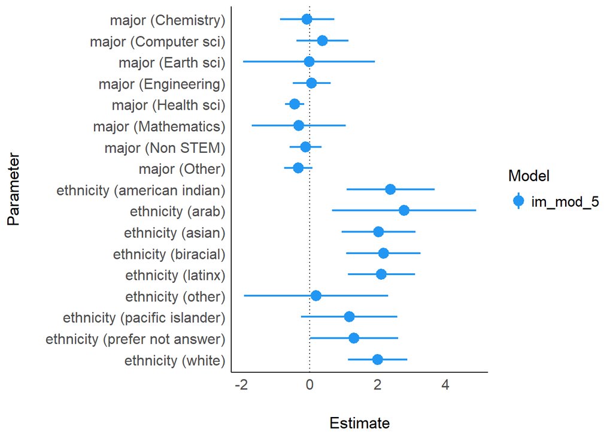

Well awesome, this gives us a great place that we can start in further data analysis in our project.

[figure not shown]

### [**NEXT**](https://pbischoff3.github.io/multi_dimensional_analysis/Gender/index.html)